# Case study 2: Interpretable ensemble models for differential expression analysis using Wilcoxon

Erina Paul

2024-08-28

This vignette highlights the example workflow for performing differential expression using interpretable ensemble models with Wilcoxon.

## Install and load packages

```r
# Clear workspace
rm(list = ls())

# Set working directory
workingDirectory='/SFS/user/ctc/pauleri/TPCPLM/analysis/'
setwd(workingDirectory)

# Load Libraries
library(tidyverse)
library(Seurat)
library(Matrix)
library(pkgmaker)
library(foreach)
library(doParallel)
library(data.table)
library(scDatasets)  # library(devtools); devtools::install_github("gongx030/scDatasets")
library(SummarizedExperiment)
library(Biobase)
library(SC2P) # library(devtools); install_github("haowulab/SC2P")
library(SingleCellExperiment)
library(gridExtra)
pacman::p_load('reshape2')
library(DESeq2)
library(metapod)
library(scran)
library(cowplot)

# Load Source Files
pkgmaker::source_files('./Codes/Real_Data/helper', '*.R')
```

## Data

The dataset (referred to here as the Brain data) contains expression counts of 100 single‐cells generated from two different cell types: oligodentrocytes cells ($N = 38$) and astrocytes cells ($N = 62$). This dataset is obtained from the R package SC2P) and is available from the Gene Expression Omnibus database under accession number GSE67835.

### Load data

```r
data(brain_scRNAseq)

# Force the consistent format
features = as.data.frame(t(Y))
metadata = as.data.frame(design$celltype)
names(metadata) = 'CellType'
metadata$CellType = factor(metadata$CellType, levels = unique(metadata$CellType))
rownames(features) = rownames(metadata)=paste('cell', 1:nrow(features), sep ='')
colnames(features) = trimws(colnames(features)) # remove white space
```

### Extract other parameters

```r
libSize = features %>% rowSums()
ID = features %>% rownames()
physeq = list(features = features,
              metadata = metadata,
              libSize = libSize,
              ID = ID)
```

## Output

Here, we fit the two part model using DESeq2 and Wilcoxon. First, we fit the models separately and then combine the two-part model using the p-value combination method.

### Run DESeq2

```r
# Standard DESeq2 pipeline
formula = as.formula(paste('~', paste(colnames(metadata), collapse = "+"), sep=''))
x = DESeqDataSetFromMatrix(countData = t(as.matrix(features)), colData = metadata, design = formula)
gm_mean = function(x, na.rm=TRUE){
  exp(sum(log(x[x > 0]), na.rm=na.rm) / length(x))
}
geoMeans = apply(counts(x), 1, gm_mean)
x = estimateSizeFactors(x, geoMeans = geoMeans)
fit = DESeq(x)
```

```
#> -- replacing outliers and refitting for 6495 genes
#> -- DESeq argument 'minReplicatesForReplace' = 7
#> -- original counts are preserved in counts(dds)
```

```r
# Combine results
coef = coef(fit)[,-1]
pval = results(fit,name=resultsNames(fit)[2])$pvalue
paras = cbind.data.frame(coef, pval)
paras$feature = rownames(paras)
paras$metadata = names(metadata)
paras$adjPval = as.numeric(p.adjust(paras$pval, method = 'BY'))
paras = paras[order(paras$adjPval, decreasing = FALSE),]

# Return output from DESeq2
paras_CR = paras %>% dplyr::rename(pval_CR = pval)
```

### Run Wilcoxon for presence/absense test

```r
paras_WC = fit.Wilcoxon(features = features,
                  metadata = metadata,
                  libSize = libSize,
                  ID = ID)
```

### Combine results

```r
paras = paras_CR %>% right_join(paras_WC, by=c("feature","metadata"))
```

### Attach p-value

After computation, Brain is a data frame containing coefficient estimates, p-values, and multiplicity-adjusted p-values along with other parameter estimates from the fitted per-feature models and two-part models. By default, p-values are adjusted with the Vanilla and Cauchy Combination Test (CCT) method. Top 10 statistically significant differntially expressed genes (observed FDR smaller than 0.05) are represented in the table and figure.

#### Vanilla

```r
# P-value: Vanilla
parasVanilla = paras
parasVanilla$pval = pmin(parasVanilla$pval_CR, parasVanilla$pval)

# Adjusted p-value using Vanilla
parasVanilla$qval = as.numeric(p.adjust(parasVanilla$pval, method = 'BY'))

# Return output
parasVanilla = parasVanilla[order(parasVanilla$qval, decreasing = FALSE),]
finresVanilla = list(res = parasVanilla, features = features)
finresVanilla$res[1:10,]
```

```
#>       coef.x       pval_CR  feature metadata       adjPval          pval coef.y
#> 1   29.34756 1.714225e-229   SH3TC2 CellType 1.761574e-224 1.714225e-229  341.0
#> 2  -25.90413 7.989120e-154    CXCR7 CellType 4.104894e-149 7.989120e-154 1805.0
#> 3   26.30809 1.462072e-132 ADAMTS18 CellType 4.806699e-128 1.462072e-132  552.5
#> 4  -25.83149 1.871001e-132  SHROOM3 CellType 4.806699e-128 1.871001e-132 1748.0
#> 5  -24.51838 8.248278e-132 FLJ46906 CellType 1.695221e-127 8.248278e-132 1786.0
#> 6  -25.32048 7.617051e-128   PRDM16 CellType 1.304574e-123 7.617051e-128 1729.0
#> 7  -23.33830 3.133517e-118   CHI3L1 CellType 4.600097e-114 3.133517e-118 1862.0
#> 8   27.64356 2.048369e-114    TMCC3 CellType 2.631184e-110 2.048369e-114  607.5
#> 9  -25.00825 1.703267e-105 KIAA1671 CellType 1.944792e-101 1.703267e-105 1634.0
#> 10 -10.17400 2.414322e-103     RYR3 CellType  2.481008e-99 2.414322e-103 2353.0
#>             qval
#> 1  1.761574e-224
#> 2  4.104894e-149
#> 3  4.806699e-128
#> 4  4.806699e-128
#> 5  1.695221e-127
#> 6  1.304574e-123
#> 7  4.600097e-114
#> 8  2.631184e-110
#> 9  1.944792e-101
#> 10  2.481008e-99
```

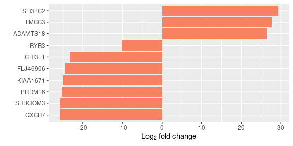

```r
# Boxplot (Top 10)
dataVanilla = finresVanilla$res[1:10,]

plot1 = dataVanilla%>%
  mutate(feature = reorder(feature, coef.x)) %>%
  ggplot(aes(x=feature, y = coef.x)) +
  geom_bar(stat="identity", fill="#f68060") +
  coord_flip() +
  ylab(expression('Log'[2]*' fold change'))+
  xlab("")

grid.arrange(plot1, ncol=1)
```

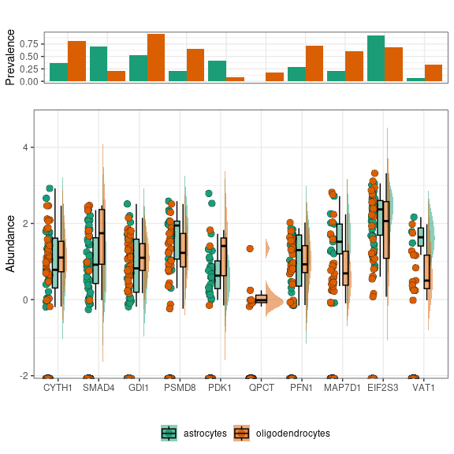

```r
# Raincloud plot (Top 10)
output = finresVanilla[["res"]]
data = output[which(output$pval<=0.05 & output$pval_CR>=0.5),][1:10,]

scale.factor = SCRANnorm(physeq$features)
norm.feature = physeq$features/scale.factor
data1 = norm.feature[,data$feature]

data.plot = cbind(data1, metadata)
plot_data = gather(data.plot, feature, value, data$feature, factor_key=TRUE)

plot_data$value <- log10(plot_data$value)
plot_data$value[is.nan(plot_data$value)] <- -Inf


p1 = ggplot(plot_data, aes(x = feature, y = value, fill = CellType)) +
  geom_flat_violin(aes(fill =  CellType), position = position_nudge(x = .1, y = 0), adjust = 1.5, trim = FALSE, alpha = .5, colour = NA)+
  geom_point(aes(x = as.numeric(feature)-.25, y = value, colour =  CellType),
             position = position_jitter(width = .05),
             size = 3, shape = 21, stroke = 0.15, color = 'black')+
  geom_boxplot(aes(x = feature, y = value, fill =  CellType),outlier.shape = NA, alpha = .5, width = .3, colour = "black")+
  scale_colour_brewer(palette = "Dark2") +
  scale_fill_brewer(palette = "Dark2") +
  theme_bw() +
  theme(legend.title = element_blank(),
        legend.position = "bottom") +
  ggtitle('') + xlab('') + ylab('Abundance')

#######################
# Bar Plot for Zeroes #
#######################

rep_data2 <- plot_data %>%
  mutate(value2 = ifelse(is.finite(value), 1, 0)) %>%
  group_by(feature, CellType) %>%
  summarise(prevalence = mean(value2))
p2<-ggplot(data=rep_data2, aes(x=feature, y=prevalence, fill=CellType)) +
  geom_bar(stat="identity", position=position_dodge()) +
  scale_colour_brewer(palette = "Dark2") +
  scale_fill_brewer(palette = "Dark2") +
  theme_bw() +
  theme(legend.position = "none",
        axis.title.x=element_blank(),
        axis.text.x=element_blank(),
        axis.ticks.x=element_blank(),
        plot.title = ggplot2::element_text(hjust = 0.5, size = 20)) +
  ggtitle('') + xlab('') +   ylab('Prevalence')

###########
# Combine #
###########

p<-plot_grid(p2, NULL, p1, ncol = 1, rel_heights = c(1.25, -0.1, 5))
p
```

#### CCT

```r
# P-value: CCT
parasCCT = paras_CR %>% right_join(paras_WC, by=c("feature","metadata"))
parasCCT$pval = combinePvalCCT(parasCCT$pval_CR, parasCCT$pval)

# Adjusted p-value using CCT
parasCCT$qval = as.numeric(p.adjust(parasCCT$pval, method = 'BY'))

# Return output
parasCCT = parasCCT[order(parasCCT$qval, decreasing = FALSE),]
finresCCT = list(res = parasCCT, features = features)
finresCCT$res[1:10,]
```

```
#>       coef.x       pval_CR  feature metadata       adjPval          pval coef.y
#> 1   29.34756 1.714225e-229   SH3TC2 CellType 1.761574e-224 3.428451e-229  341.0
#> 2  -25.90413 7.989120e-154    CXCR7 CellType 4.104894e-149 1.597824e-153 1805.0
#> 3   26.30809 1.462072e-132 ADAMTS18 CellType 4.806699e-128 2.924144e-132  552.5
#> 4  -25.83149 1.871001e-132  SHROOM3 CellType 4.806699e-128 3.742002e-132 1748.0
#> 5  -24.51838 8.248278e-132 FLJ46906 CellType 1.695221e-127 1.649656e-131 1786.0
#> 6  -25.32048 7.617051e-128   PRDM16 CellType 1.304574e-123 1.523410e-127 1729.0
#> 7  -23.33830 3.133517e-118   CHI3L1 CellType 4.600097e-114 6.267035e-118 1862.0
#> 8   27.64356 2.048369e-114    TMCC3 CellType 2.631184e-110 4.096738e-114  607.5
#> 9  -25.00825 1.703267e-105 KIAA1671 CellType 1.944792e-101 3.406533e-105 1634.0
#> 10 -10.17400 2.414322e-103     RYR3 CellType  2.481008e-99 4.828643e-103 2353.0
#>             qval
#> 1  3.534662e-224
#> 2  8.236617e-149
#> 3  9.644816e-128
#> 4  9.644816e-128
#> 5  3.401522e-127
#> 6  2.617674e-123
#> 7  9.230262e-114
#> 8  5.279565e-110
#> 9  3.902295e-101
#> 10  4.978231e-99
```

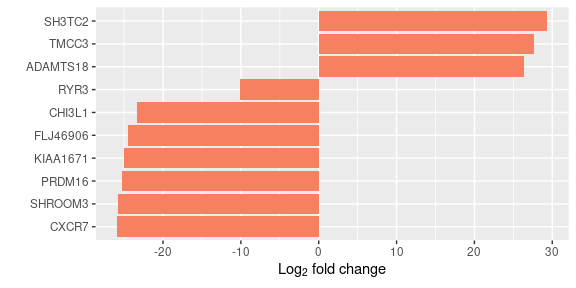

```r
# Boxplot (Top 10)
dataCCT = finresCCT$res[1:10,]

plot1 = dataCCT%>%
  mutate(feature = reorder(feature, coef.x)) %>%
  ggplot(aes(x=feature, y = coef.x)) +
  geom_bar(stat="identity", fill="#f68060") +
  coord_flip() +
  ylab(expression('Log'[2]*' fold change'))+
  xlab("")

grid.arrange(plot1, ncol=1)
```

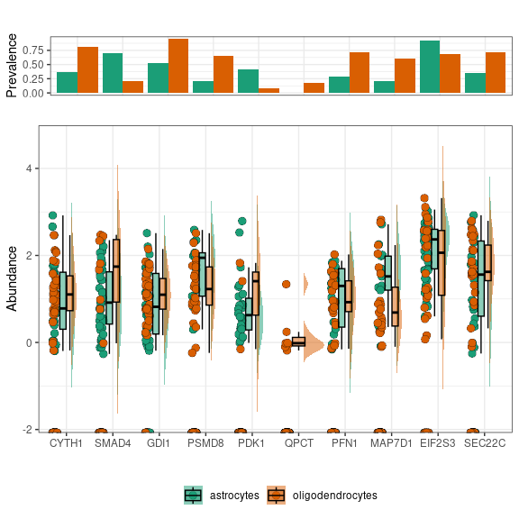

```r
# Raincloud plot (Top 10)
output = finresCCT[["res"]]
data = output[which(output$pval<=0.05 & output$pval_CR>=0.5),][1:10,]

scale.factor = SCRANnorm(physeq$features)
norm.feature = physeq$features/scale.factor
data1 = norm.feature[,data$feature]

data.plot = cbind(data1, metadata)
plot_data = gather(data.plot, feature, value, data$feature, factor_key=TRUE)

plot_data$value <- log10(plot_data$value)
plot_data$value[is.nan(plot_data$value)] <- -Inf


p1 = ggplot(plot_data, aes(x = feature, y = value, fill = CellType)) +
  geom_flat_violin(aes(fill =  CellType), position = position_nudge(x = .1, y = 0), adjust = 1.5, trim = FALSE, alpha = .5, colour = NA)+
  geom_point(aes(x = as.numeric(feature)-.25, y = value, colour =  CellType),
             position = position_jitter(width = .05),
             size = 3, shape = 21, stroke = 0.15, color = 'black')+
  geom_boxplot(aes(x = feature, y = value, fill =  CellType),outlier.shape = NA, alpha = .5, width = .3, colour = "black")+
  scale_colour_brewer(palette = "Dark2") +
  scale_fill_brewer(palette = "Dark2") +
  theme_bw() +
  theme(legend.title = element_blank(),
        legend.position = "bottom") +
  ggtitle('') + xlab('') + ylab('Abundance')

#######################
# Bar Plot for Zeroes #
#######################

rep_data2 <- plot_data %>%
  mutate(value2 = ifelse(is.finite(value), 1, 0)) %>%
  group_by(feature, CellType) %>%
  summarise(prevalence = mean(value2))
p2<-ggplot(data=rep_data2, aes(x=feature, y=prevalence, fill=CellType)) +
  geom_bar(stat="identity", position=position_dodge()) +
  scale_colour_brewer(palette = "Dark2") +
  scale_fill_brewer(palette = "Dark2") +
  theme_bw() +
  theme(legend.position = "none",
        axis.title.x=element_blank(),
        axis.text.x=element_blank(),
        axis.ticks.x=element_blank(),
        plot.title = ggplot2::element_text(hjust = 0.5, size = 20)) +
  ggtitle('') + xlab('') +   ylab('Prevalence')

###########
# Combine #
###########

p<-plot_grid(p2, NULL, p1, ncol = 1, rel_heights = c(1.25, -0.1, 5))
p
```

## Number of significant genes at 5% FDR

```r
nrow(finresVanilla$res[finresVanilla$res$qval<0.05,])
```

```
#> [1] 2102
```

```r
nrow(finresCCT$res[finresCCT$res$qval<0.05,])
```

```
#> [1] 1858
```

```r
nrow(finresCCT$res[finresCCT$res$adjPval<0.05,])
```

```
#> [1] 1584
```